# Practical Machine Learning Course Project

Antoinette Mills

March 28, 2016

**Background**

Using devices such as Jawbone Up, Nike FuelBand, and Fitbit it is now possible to collect a large amount of data about personal activity relatively inexpensively. These type of devices are part of the quantified self movement - a group of enthusiasts who take measurements about themselves regularly to improve their health, to find patterns in their behavior, or because they are tech geeks. One thing that people regularly do is quantify how much of a particular activity they do, but they rarely quantify how well they do it. In this project, your goal will be to use data from accelerometers on the belt, forearm, arm, and dumbell of 6 participants. They were asked to perform barbell lifts correctly and incorrectly in 5 different ways. More information is available from the website here: http://groupware.les.inf.puc-rio.br/har (see the section on the Weight Lifting Exercise Dataset).

**Data**

The training data for this project are available here:

https://d396qusza40orc.cloudfront.net/predmachlearn/pml-training.csv

The test data are available here:

https://d396qusza40orc.cloudfront.net/predmachlearn/pml-testing.csv

The data for this project come from this source: http://groupware.les.inf.puc-rio.br/har. If you use the document you create for this class for any purpose please cite them as they have been very generous in allowing their data to be used for this kind of assignment.

```r
library(lattice)
library(ggplot2)
library(graphics)
library(e1071)
library(caret)
library(rpart.plot)
library(rpart)
library(rattle)
library(randomForest)
library(RColorBrewer)
```

### Data Readiness

**Load & Verify Data**

First step is to load clean data from both the testing and the training datasets:

```r
training<-read.csv("C:/Users/antmills/Documents/GitHub/Practical Machine Learning/pml-training.csv",na.strings=c("NA","#DIV/0!",""))
testing<-read.csv("C:/Users/antmills/Documents/GitHub/Practical Machine Learning/pml-testing.csv",na.strings=c("NA","#DIV/0!",""))
```

Next, we then separate the data to be used for cross verification:

```r
inTrain <- createDataPartition(y=training$classe, p=0.6, list=FALSE)
myDataTrain <- training[inTrain, ];
myDataTest <- training[-inTrain, ]
```

We then examine the size and structure of the data (respectively):

```r
dim(myDataTrain)
```

```
## [1] 11776   160
```

```r
dim(myDataTest)
```

```
## [1] 7846  160
```

**Data Clean Up**

```r
nzv <- nearZeroVar(myDataTrain, saveMetrics=TRUE)
myDataTrain <- myDataTrain[,nzv$nzv==FALSE]

nzv<- nearZeroVar(myDataTest,saveMetrics=TRUE)
myTesting <- myDataTest[,nzv$nzv==FALSE]

#Remove the first column of the myTraining data set
myDataTrain <- myDataTrain[c(-1)]

#Clean variables with more than 60% NA
trainingV3 <- myDataTrain
for(i in 1:length(myDataTrain)) {
        if( sum( is.na( myDataTrain[, i] ) ) /nrow(myDataTrain) >= .7) {
                for(j in 1:length(trainingV3)) {
                        if( length( grep(names(myDataTrain[i]), names(trainingV3)[j]) ) == 1)  {
                                trainingV3 <- trainingV3[ , -j]
                        }
                }
        }
}

myDataTrain <- trainingV3
rm(trainingV3)

clean1 <- colnames(myDataTrain)
clean2 <- colnames(myDataTrain[, -58])
myTesting <- myDataTest[clean1]
testing <- testing[clean2]

for (i in 1:length(testing) ) {
        for(j in 1:length(myDataTrain)) {
                if( length( grep(names(myDataTrain[i]), names(testing)[j]) ) == 1)  {
                        class(testing[j]) <- class(myDataTrain[i])
                }
        }
}

testing <- rbind(myDataTrain[2, -58] , testing)
testing <- testing[-1,]
```

### Predictions

**Random Forest Prediction**

```r
set.seed(12345)
modFitB1 <- randomForest(classe ~ ., data=myDataTrain)
predictionB1 <- predict(modFitB1, myDataTest, type = "class")
cmrf <- confusionMatrix(predictionB1, myDataTest$classe)
cmrf
```

```
## Confusion Matrix and Statistics
##
##           Reference
## Prediction    A    B    C    D    E
##          A 2227    4    0    0    0
##          B    5 1514    7    0    0
##          C    0    0 1360    2    0
##          D    0    0    1 1283    6
##          E    0    0    0    1 1436
##
## Overall Statistics
##
##                Accuracy : 0.9967
##                  95% CI : (0.9951, 0.9978)
##     No Information Rate : 0.2845
##     P-Value [Acc > NIR] : < 2.2e-16
##
##                   Kappa : 0.9958
##  Mcnemar's Test P-Value : NA
##
## Statistics by Class:
##
##                      Class: A Class: B Class: C Class: D Class: E
## Sensitivity            0.9978   0.9974   0.9942   0.9977   0.9958
## Specificity            0.9993   0.9981   0.9997   0.9989   0.9998
## Pos Pred Value         0.9982   0.9921   0.9985   0.9946   0.9993
## Neg Pred Value         0.9991   0.9994   0.9988   0.9995   0.9991
## Prevalence             0.2845   0.1935   0.1744   0.1639   0.1838
## Detection Rate         0.2838   0.1930   0.1733   0.1635   0.1830
## Detection Prevalence   0.2843   0.1945   0.1736   0.1644   0.1832
## Balanced Accuracy      0.9985   0.9977   0.9969   0.9983   0.9978
```

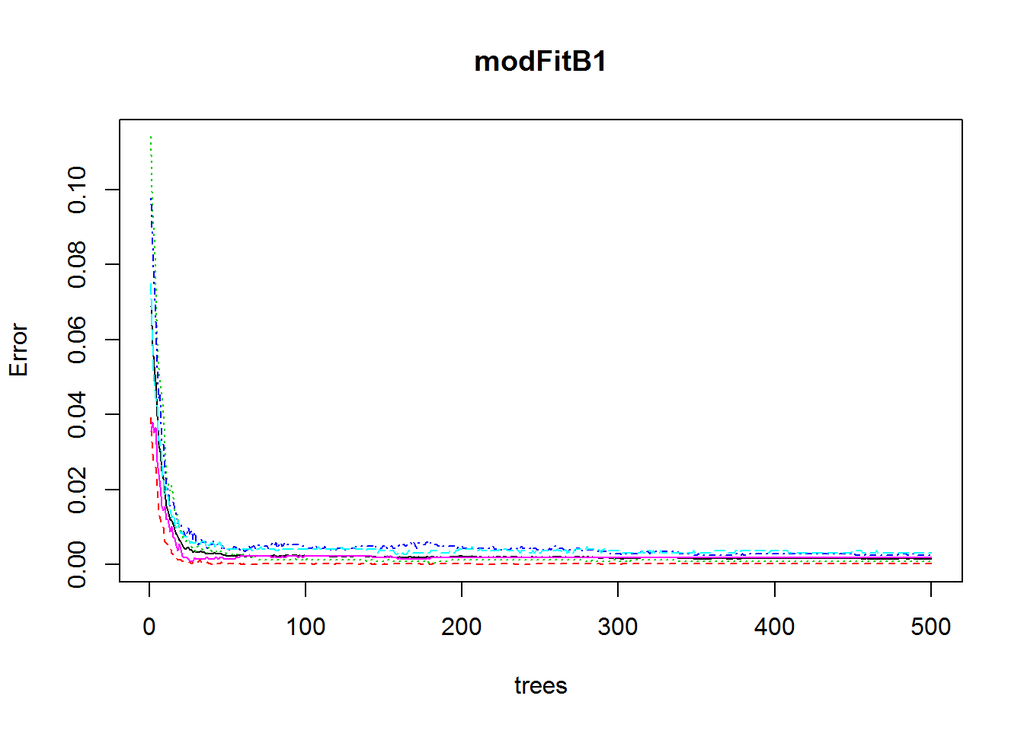

```r
plot(modFitB1)
```

**Decision Trees**

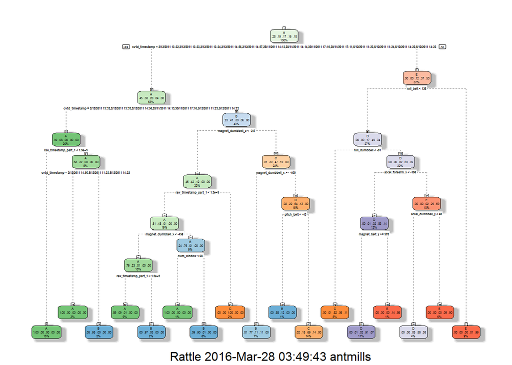

```r
set.seed(12345)
modFitA1 <- rpart(classe ~ ., data=myDataTrain, method="class")
fancyRpartPlot(modFitA1)
```

```r
predictionsA1 <- predict(modFitA1, myDataTest, type = "class")
cmtree <- confusionMatrix(predictionsA1, myDataTest$classe)
cmtree
```

```
## Confusion Matrix and Statistics
##
##           Reference
## Prediction    A    B    C    D    E
##          A 2150   59    4    2    0
##          B   56 1241   88   62    0
##          C   26  203 1236  213   56
##          D    0   15   39  943  166
##          E    0    0    1   66 1220
##
## Overall Statistics
##
##                Accuracy : 0.8654
##                  95% CI : (0.8577, 0.8729)
##     No Information Rate : 0.2845
##     P-Value [Acc > NIR] : < 2.2e-16
##
##                   Kappa : 0.8299
##  Mcnemar's Test P-Value : NA
##
## Statistics by Class:
##
##                      Class: A Class: B Class: C Class: D Class: E
## Sensitivity            0.9633   0.8175   0.9035   0.7333   0.8460
## Specificity            0.9884   0.9674   0.9231   0.9665   0.9895
## Pos Pred Value         0.9707   0.8576   0.7128   0.8108   0.9479
## Neg Pred Value         0.9854   0.9567   0.9784   0.9487   0.9662
## Prevalence             0.2845   0.1935   0.1744   0.1639   0.1838
## Detection Rate         0.2740   0.1582   0.1575   0.1202   0.1555
## Detection Prevalence   0.2823   0.1844   0.2210   0.1482   0.1640
## Balanced Accuracy      0.9758   0.8925   0.9133   0.8499   0.9178
```

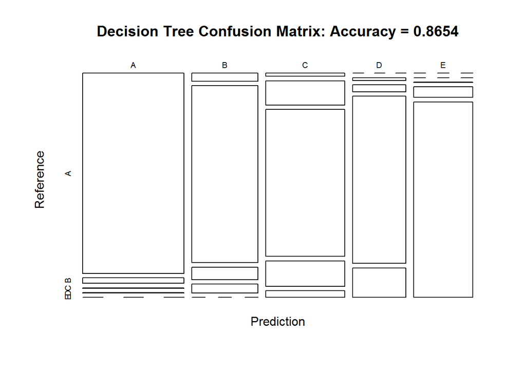

```r
plot(cmtree$table, col = cmtree$byClass, main = paste("Decision Tree Confusion Matrix: Accuracy =", round(cmtree$overall['Accuracy'], 4)))
```